# 12_sppxpixel_birds_vocc_revised.qmd

```r
library(tidyverse)
library(terra)
library(sf)
library(rnaturalearth)
library(here)
library(iucnredlist) ### remotes::install_github("IUCN-UK/iucnredlist")
library(janitor)
library(cowplot)
```

This document investigates the Sorensen Similarity Index for bird species in the Lawler paper at both the species and trait level. However, instead of the Lawler projections, we use updated future species ranges created from the VoCC package. Visualizations are at the pixel level. Categorical trait data is from AVONET. IUCN threat data was created in 9_lawler_iucn_threat_status.qmd

```r
# Functions
source(here("common_fxns.R"))
```

```r
# Read in VoCC projected future species range (filtering for rcp 8.5)
spp_rcp85_mapfiles <- list.files(here_anx('/spp_range_proj_cordex/spp_range_projections'),
                           full.names = TRUE, recursive = TRUE, pattern = 'rcp8.5')
spp_rcp85 <- data.frame(f = spp_rcp85_mapfiles,
                         spp = basename(spp_rcp85_mapfiles) %>%
                           str_remove('spp_proj_rcp8.5_2056-2060_') %>%
                           str_remove('.tif') %>%
                           str_replace_all('_', ' '))
```

## Gather maps and aggregate

Following the method in 2_combine_spp_scenarios.qmd: For all the Lawler birds species (301) gather the future maps (just one per species unlike the Lawler data). Then crop the historical maps to the same extent.

### Aggregate future projections

- Value = 1: historical areas only (no trajectories, no analog - these are range cells outside bounds of climate map, so no trajectories could be calculated) *Value = 2: trajectory only (outside historic bounds and analog bounds - transit cell)* Value = 3: historical + trajectory (no analog; species had historical range but will not persist in future) *Value = 4: analog only (no historical, no trajectory - these are climate analogs but are not reachable)* Value = 5: analog + historical only, no trajectory (these should not occur) *Value = 6: analog + trajectory only (novel and reachable analog locations, outside of historical locations)* Value = 7: analog + trajectory + historical (persistence of original range into the future range)

**Values 1, 3, and 7 create historic range** **Values 6 and 7 are create future range**

### crop future maps

```r
### set up extent for continental US
us_extent <- ext(c(xmin = -130, xmax = -65, ymin = 23, ymax = 50))

### Aggregate over the vector of species names
spp_vec <- spp_rcp85$spp %>% unique()
```

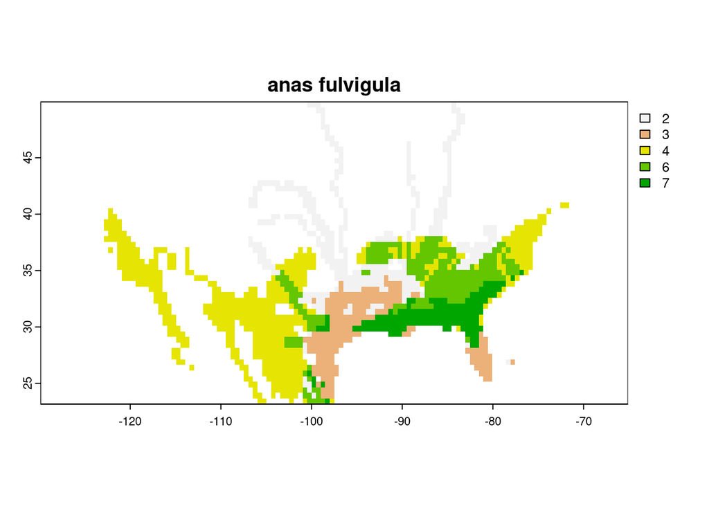

```r
range_vocc <- lapply(spp_vec, FUN = agg_scenario, df = spp_rcp85) %>%
  setNames(spp_vec) %>%
  rast()

# Test out one of the maps
x <- range_vocc[[16]]
plot(x, main = names(range_vocc)[16])
```

## Generate jurisdiction map

Let’s generate a simple jurisdiction map - US states, and Canada and Mexico.

```r
states_sf <- ne_states(returnclass = 'sf', country = c('Mexico', 'Canada', 'United States of America'))

state_id_df <- states_sf %>%
  st_drop_geometry() %>%
  mutate(juris = ifelse(adm0_a3 == 'USA', name, admin)) %>%
  dplyr::select(id = gn_id, juris)
### plot(states_sf %>% select(iso_a2))
states_rast <- rasterize(states_sf, range_vocc, field = 'gn_id')
#plot(states_rast)
```

```r
# Function to get pixels instead of jurisdictions
extract_jurisdictions_pixels <- function(spp, range_r, juris_r) {
  ### spp <- spp_vec[1]
  ### future_r = future_rast; hist_r = hist_rast; juris_r = states_rast
  s_r_r <- range_r[[names(range_r) == spp]]
  s_df <- data.frame(values(s_r_r),
                     values(juris_r)) %>%
    setNames(c('range_value', 'id')) %>%
    mutate(pixel_id = row_number()) %>%
    filter(!is.na(id)) %>%
    filter(!is.na(range_value)) #%>%
    #group_by(id) %>%
    #summarize(n_historical = sum(historical > .25),
              #n_future = sum(future > .5))

  return(s_df)
}
```

## Rough pass at classification?

Assign any pixel greater than zero to presence (1). Count up the spp ineach pixel

```r
pixel_spp_list <- lapply(spp_vec, FUN = extract_jurisdictions_pixels,
                         range_r = range_vocc,
                         juris_r = states_rast) %>%
  setNames(spp_vec) %>%
  bind_rows(.id = 'spp') %>%
  left_join(state_id_df, by = 'id') #%>%
  ### note, Canada and Mexico have multiple jurisdictions (provinces and states)
  ### so sum up all those instances
  #group_by(spp, juris) %>%
  #summarize(n_historical = sum(n_historical),
            #n_future = sum(n_future),
            #.groups = 'drop')
```

```r
# Add a row classifying the the range values into future range (6, 7) or historic range (1, 3, 7)
# Currently no raster values of 1 b/c map is cropped
pixel_spp_range <- pixel_spp_list %>%
  mutate(historic_range = ifelse(range_value %in% c(1, 3, 7), 1, 0),
        future_range = ifelse(range_value %in% c(6, 7), 1, 0))
```

```r
# Count up species by pixel
pixel_spp_count <- pixel_spp_range %>%
  group_by(pixel_id, juris) %>%
  summarize(historic_spp_count = sum(historic_range, na.rm = TRUE),
            future_spp_count = sum(future_range, na.rm = TRUE))
```

```r
# Create a blank raster with same extent as x = spp_rcp85[[16]]
id_rast <- rast(x)
```

```r
# Assign IDs and then convert to sf
values(id_rast ) <- 1:ncell(x)
```

```r
id_rast_sf <- id_rast %>%
  stars::st_as_stars() %>%
  st_as_sf() %>%
  rename("pixel_id" = "anas fulvigula")
```

```r
# Merge in species count
pixel_spp_count_sf <- inner_join(id_rast_sf, pixel_spp_count)
```

```r
historic_spp_num <- ggplot() +
  geom_sf(data = pixel_spp_count_sf, aes(geometry = geometry, fill = historic_spp_count, color = historic_spp_count)) +
  scale_fill_viridis_c(option = "plasma", limits = c(1,200)) +
  scale_color_viridis_c(option = "plasma", limits = c(1,200)) +
  geom_sf(data = pixel_spp_count_sf %>% filter(historic_spp_count == 0), aes(geometry = geometry), fill = "gray40", color = "grey40") +
  labs(title = "VoCC historic number of bird species",
       subtitle = "(0 species in gray)",
       fill = "count",
       color = "count")
```

```r
future_spp_num <- ggplot() +
  geom_sf(data = pixel_spp_count_sf, aes(geometry = geometry, fill = future_spp_count, color = future_spp_count)) +
  scale_fill_viridis_c(option = "plasma", limits = c(1,200)) +
  scale_color_viridis_c(option = "plasma", limits = c(1,200)) +
  geom_sf(data = pixel_spp_count_sf %>% filter(future_spp_count == 0), aes(geometry = geometry), fill = "gray40", color = "grey40") +
  labs(title = "VoCC future number of bird species",
       subtitle = "(0 species in gray)",
       fill = "count",
       color = "count")
```

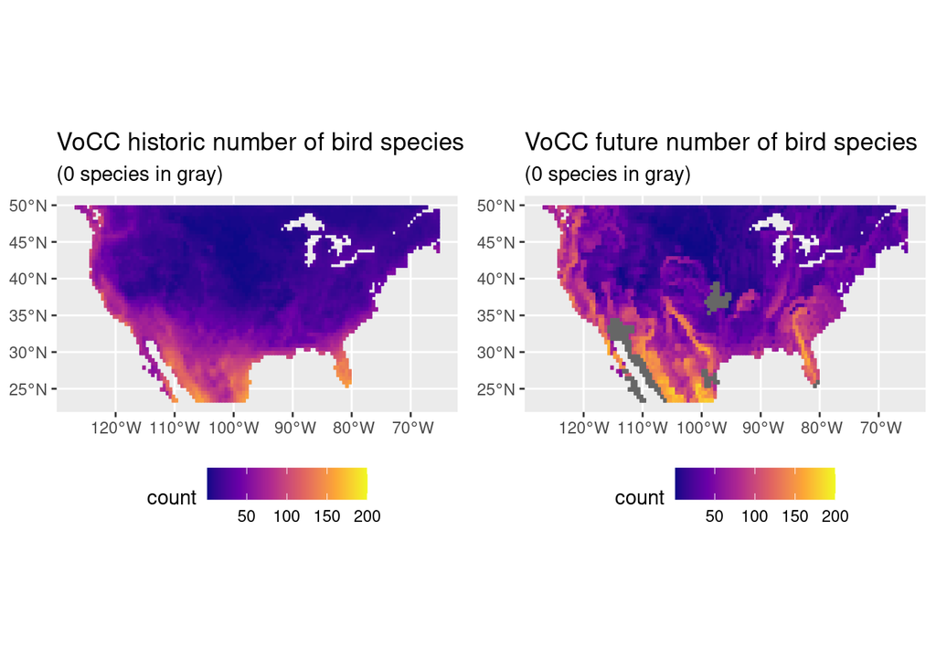

```r
plot_grid(historic_spp_num + theme(legend.position = 'bottom'),
          future_spp_num + theme(legend.position = 'bottom'))
```

## How do these same species compare to the Lawler data?

```r
# Read in Lawler data
lawler_spp_mapfiles <- list.files(here_anx('/data_lawler_2020/species_projections'),
                           full.names = TRUE, recursive = TRUE, pattern = '.tif')
lawler_spp_all_df <- data.frame(f = lawler_spp_mapfiles,
                         spp = basename(lawler_spp_mapfiles) %>%
                           str_remove('(_gf85|_in85|_mc85|_bias).+') %>%
                           str_replace_all('_', ' '),
                         tax = basename(dirname(lawler_spp_mapfiles)))
```

```r
# Filter for just Lawler birds
birds_all_df <- lawler_spp_all_df %>%
  filter(tax == "Birds")
```

```r
birds_all <- birds_all_df %>%
  group_by(spp, tax) %>%
  summarize(files = n())
```

For each species in the sample, aggregate the three future scenarios into a single map. Crop to the lower continental US states.

```r
### Aggregate over the vector of species names
lawler_spp_vec <- birds_all_df$spp %>% unique()

lawler_future_rast <- lapply(lawler_spp_vec, FUN = agg_scenario, df = birds_all_df) %>%
  setNames(lawler_spp_vec) %>%
  rast()

#x <- future_rast[[1]]
#plot(x, main = names(future_rast)[1])
```

### crop historical maps

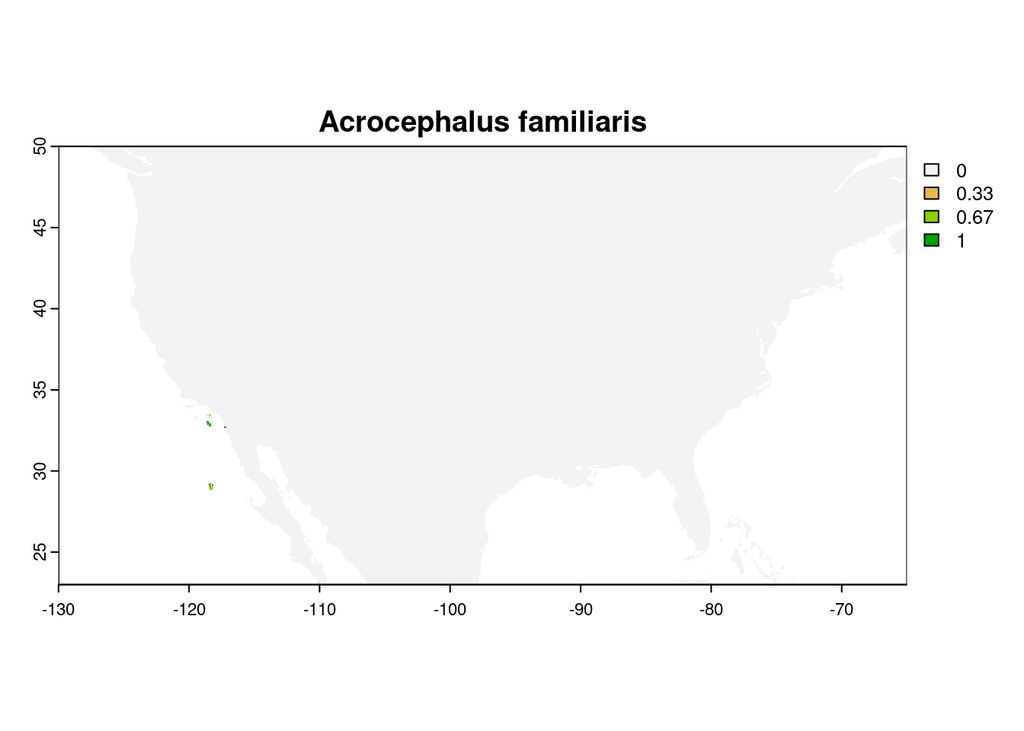

```r
lawler_hist_rast <- lapply(lawler_spp_vec, FUN = agg_scenario, df = birds_all_df,
                    scenario = 'historical') %>%
  setNames(lawler_spp_vec) %>%
  rast()

x_lawler <- lawler_future_rast[[1]]
plot(x_lawler, main = names(lawler_future_rast)[1])
```

## Generate jurisdiction map

Let’s generate a simple jurisdiction map - US states, and Canada and Mexico.

```r
states_sf <- ne_states(returnclass = 'sf', country = c('Mexico', 'Canada', 'United States of America'))

state_id_df <- states_sf %>%
  st_drop_geometry() %>%
  mutate(juris = ifelse(adm0_a3 == 'USA', name, admin)) %>%
  dplyr::select(id = gn_id, juris)
### plot(states_sf %>% select(iso_a2))
lawler_states_rast <- rasterize(states_sf, lawler_hist_rast, field = 'gn_id')
#plot(lawler_states_rast)
```

## Rough pass at classification?

For each spp let’s create a dataframe of jurisdictions and cell values…

```r
# Function to get pixels instead of jurisdictions
lawler_extract_jurisdictions_pixels <- function(spp, future_r, hist_r, juris_r) {
  ### spp <- spp_vec[1]
  ### future_r = future_rast; hist_r = hist_rast; juris_r = states_rast
  s_f_r <- future_r[[names(future_r) == spp]]
  s_h_r <- hist_r[[names(hist_r) == spp]]
  s_df <- data.frame(values(s_h_r),
                     values(s_f_r),
                     values(juris_r)) %>%
    setNames(c('historical', 'future', 'id')) %>%
    mutate(pixel_id = row_number()) %>%
    filter(!is.na(id)) %>%
    filter(!is.na(historical) | !is.na(future)) #%>%
    #group_by(id) %>%
    #summarize(n_historical = sum(historical > .25),
              #n_future = sum(future > .5))

  return(s_df)
}
```

```r
lawler_spp_list <- lapply(lawler_spp_vec, FUN = lawler_extract_jurisdictions_pixels,
                         future_r = lawler_future_rast,
                         hist_r = lawler_hist_rast,
                         juris_r = lawler_states_rast) %>%
  setNames(lawler_spp_vec) %>%
  bind_rows(.id = 'spp') %>%
  left_join(state_id_df, by = 'id') #%>%
  ### note, Canada and Mexico have multiple jurisdictions (provinces and states)
  ### so sum up all those instances
  #group_by(spp, juris) %>%
  #summarize(n_historical = sum(n_historical),
            #n_future = sum(n_future),
            #.groups = 'drop')
```

```r
# Create a blank raster with same extent as x = hist_rast[[1]]
id_rast_lawler <- rast(x_lawler)
```

```r
# Assign IDs and then convert to sf
values(id_rast_lawler ) <- 1:ncell(x_lawler)
```

```r
id_rast_sf_lawler <- id_rast_lawler %>%
  stars::st_as_stars() %>%
  st_as_sf() %>%
  rename("pixel_id" = "Acrocephalus familiaris")
```

## What if we focus on the Lawler species that leave FL? How do these compare to the VoCC maps?

```r
lawler_fl_species <- lawler_spp_list %>%
  filter(juris == "Florida") %>%
  mutate(spp = tolower(spp)) %>%
  group_by(spp) %>%
  summarize(historical_pixel_count = sum(historical > 0.5),
            future_pixel_count = sum(future > 0.5)) %>%
  filter(historical_pixel_count > 0 & future_pixel_count == 0) %>%
  ungroup()

lawler_left_fl <- lawler_fl_species$spp
```

```r
lawler_spp_list_left_fl <- lawler_spp_list %>%
  mutate(spp = tolower(spp)) %>%
  filter(spp %in% lawler_left_fl ) %>%
    filter(!is.na(id)) %>%
    filter(!is.na(historical) | !is.na(future)) %>%
  # Assign future pixels > 0.5 to spp prescence
  mutate(future = case_when(future > 0.5 ~ 1,
                           TRUE ~ 0))
```

```r
lawler_left_fl_count <- lawler_spp_list_left_fl %>%
  group_by(pixel_id, juris) %>%
  summarize(historic_spp_count = sum(historical, na.rm = TRUE),
            future_spp_count = sum(future, na.rm = TRUE))
```

```r
# Merge in count
lawler_left_fl_count_sf <- inner_join(id_rast_sf_lawler, lawler_left_fl_count)
```

```r
lawler_left_fl_historic_spp_num <- ggplot() +
  geom_sf(data = lawler_left_fl_count_sf, aes(geometry = geometry, fill = historic_spp_count, color = historic_spp_count)) +
  scale_fill_viridis_c(limits = c(1,53)) +
  scale_color_viridis_c(limits = c(1,53)) +
  #geom_sf(data = fl_pixel_spp_count_sf %>% filter(historic_spp_count == 0), aes(geometry = geometry), fill = "gray40", color = "grey40") +
  labs(title = "Lawler historic number of bird species (77 leave FL)",
       subtitle = "(0 species in gray)",
       fill = "count",
       color = "count")
```

```r
lawler_left_fl_future_spp_num <- ggplot() +
  geom_sf(data = lawler_left_fl_count_sf, aes(geometry = geometry, fill = future_spp_count, color = future_spp_count)) +
  scale_fill_viridis_c(limits = c(1,53)) +
  scale_color_viridis_c(limits = c(1,53)) +
  #geom_sf(data = fl_pixel_spp_count_sf %>% filter(future_spp_count == 0), aes(geometry = geometry), fill = "gray40", color = "grey40") +
  labs(title = "Lawler future number of bird species (77 leave FL)",
       subtitle = "(0 species in gray)",
       fill = "count",
       color = "count")
```

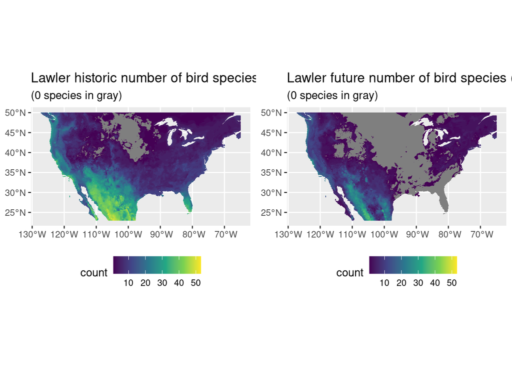

```r
plot_grid(lawler_left_fl_historic_spp_num + theme(legend.position = 'bottom'),
          lawler_left_fl_future_spp_num + theme(legend.position = 'bottom'))
```

## Filter the VoCC data for the same 77 species that left FL in the Lawler data

```r
left_fl_spp_hist_all <- pixel_spp_range %>%
  filter(spp %in% lawler_left_fl)
```

```r
# Count up species by pixel
left_fl_pixel_spp_count <- left_fl_spp_hist_all %>%
  group_by(pixel_id, juris) %>%
  summarize(historic_spp_count = sum(historic_range, na.rm = TRUE),
            future_spp_count = sum(future_range, na.rm = TRUE)) %>%
  ungroup()
```

```r
# Merge in species count
left_fl_pixel_spp_count_sf <- inner_join(id_rast_sf, left_fl_pixel_spp_count)
```

```r
left_fl_historic_spp_num <- ggplot() +
  geom_sf(data = left_fl_pixel_spp_count_sf, aes(geometry = geometry, fill = historic_spp_count, color = historic_spp_count)) +
  scale_fill_viridis_c(limits = c(1,53)) +
  scale_color_viridis_c(limits = c(1,53)) +
  #geom_sf(data = fl_pixel_spp_count_sf %>% filter(historic_spp_count == 0), aes(geometry = geometry), fill = "gray40", color = "grey40") +
  labs(title = "VoCC historic number of bird species (same 77)",
       subtitle = "(0 species in gray)",
       fill = "count",
       color = "count")
```

```r
left_fl_future_spp_num <- ggplot() +
  geom_sf(data = left_fl_pixel_spp_count_sf, aes(geometry = geometry, fill = future_spp_count, color = future_spp_count)) +
  scale_fill_viridis_c(limits = c(1,53)) +
  scale_color_viridis_c(limits = c(1,53)) +
  #geom_sf(data = fl_pixel_spp_count_sf %>% filter(future_spp_count == 0), aes(geometry = geometry), fill = "gray40", color = "grey40") +
  labs(title = "VoCC future number of bird species (same 77)",
       subtitle = "(0 species in gray)",
       fill = "count",
       color = "count")
```

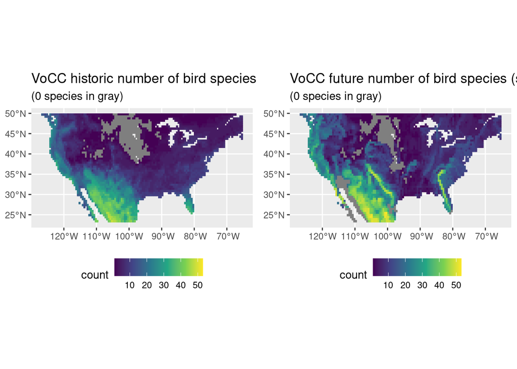

```r
plot_grid(left_fl_historic_spp_num + theme(legend.position = 'bottom'),
          left_fl_future_spp_num + theme(legend.position = 'bottom'))
```

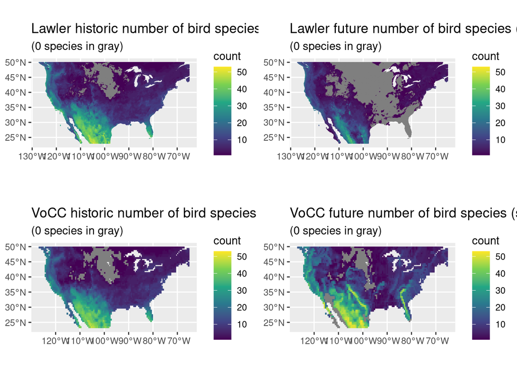

```r
plot_grid(lawler_left_fl_historic_spp_num + theme(legend.position = 'right'),
          lawler_left_fl_future_spp_num + theme(legend.position = 'right'),
          left_fl_historic_spp_num + theme(legend.position = 'right'),
          left_fl_future_spp_num + theme(legend.position = 'right'))
```

### For comparison, create the same four grid map forallthe birds

```r
lawler_spp_list_all <- lawler_spp_list %>%
  mutate(spp = tolower(spp)) %>%
    filter(!is.na(id)) %>%
    filter(!is.na(historical) | !is.na(future)) %>%
  # Assign future pixels > 0.5 to spp prescence
  mutate(future = case_when(future > 0.5 ~ 1,
                           TRUE ~ 0))
```

```r
lawler_count <- lawler_spp_list_all%>%
  group_by(pixel_id, juris) %>%
  summarize(historic_spp_count = sum(historical, na.rm = TRUE),
            future_spp_count = sum(future, na.rm = TRUE))
```

```r
# Merge in count
lawler_count_sf <- inner_join(id_rast_sf_lawler, lawler_count)
```

```r
lawler_historic_spp_num <- ggplot() +
  geom_sf(data = lawler_count_sf, aes(geometry = geometry, fill = historic_spp_count, color = historic_spp_count)) +
  scale_fill_viridis_c(option = "plasma", limits = c(1,200)) +
  scale_color_viridis_c(option = "plasma", limits = c(1,200)) +
  #geom_sf(data = fl_pixel_spp_count_sf %>% filter(historic_spp_count == 0), aes(geometry = geometry), fill = "gray40", color = "grey40") +
  labs(title = "Lawler historic number of bird species",
       subtitle = "(0 species in gray)",
       fill = "count",
       color = "count")
```

```r
lawler_future_spp_num <- ggplot() +
  geom_sf(data = lawler_count_sf, aes(geometry = geometry, fill = future_spp_count, color = future_spp_count)) +
  scale_fill_viridis_c(option = "plasma", limits = c(1,200)) +
  scale_color_viridis_c(option = "plasma", limits = c(1,200)) +
  #geom_sf(data = fl_pixel_spp_count_sf %>% filter(future_spp_count == 0), aes(geometry = geometry), fill = "gray40", color = "grey40") +
  labs(title = "Lawler future number of bird species",
       subtitle = "(0 species in gray)",
       fill = "count",
       color = "count")
```

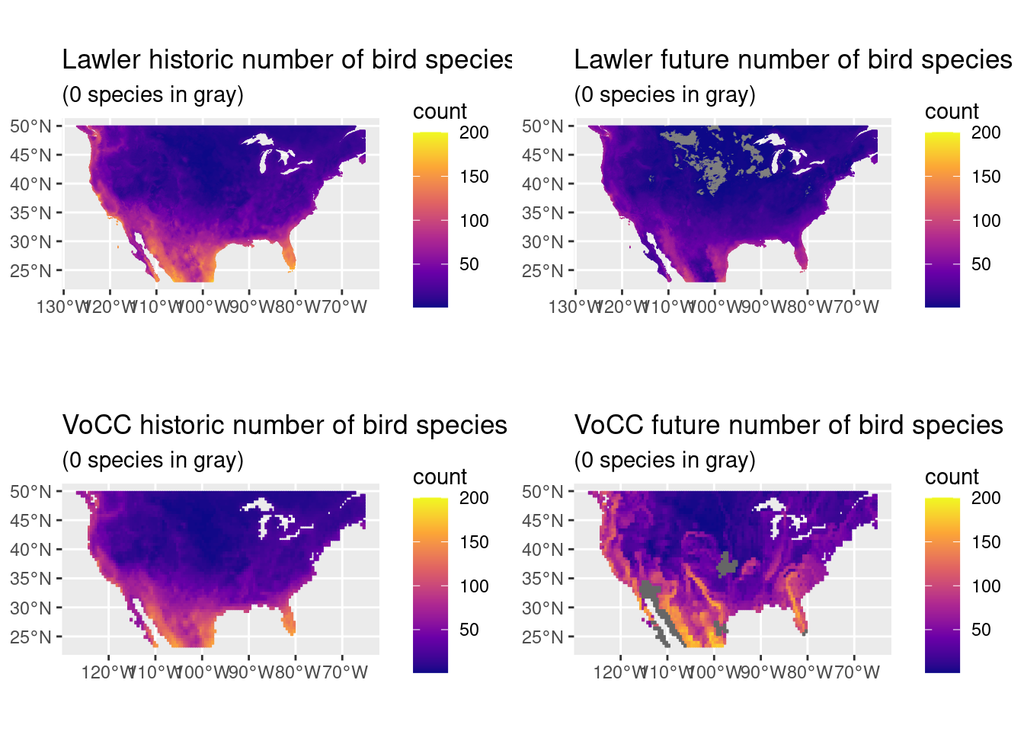

```r
plot_grid(lawler_historic_spp_num + theme(legend.position = 'right'),
          lawler_future_spp_num + theme(legend.position = 'right'),
          historic_spp_num + theme(legend.position = 'right'),
          future_spp_num + theme(legend.position = 'right'))
```

## Species and trait similiarity

```r
pixel_spp_ssi <- pixel_spp_range %>%
  group_by(pixel_id, juris) %>%
  summarize(shared = sum(historic_range == 1 & future_range == 1),
            historical_spp = sum(historic_range),
            future_spp = sum(future_range),
            ssi = (2 *shared)/(historical_spp + future_spp))
```

```r
# Add in sf
 pixel_spp_ssi_sf <- inner_join(id_rast_sf, pixel_spp_ssi)
```

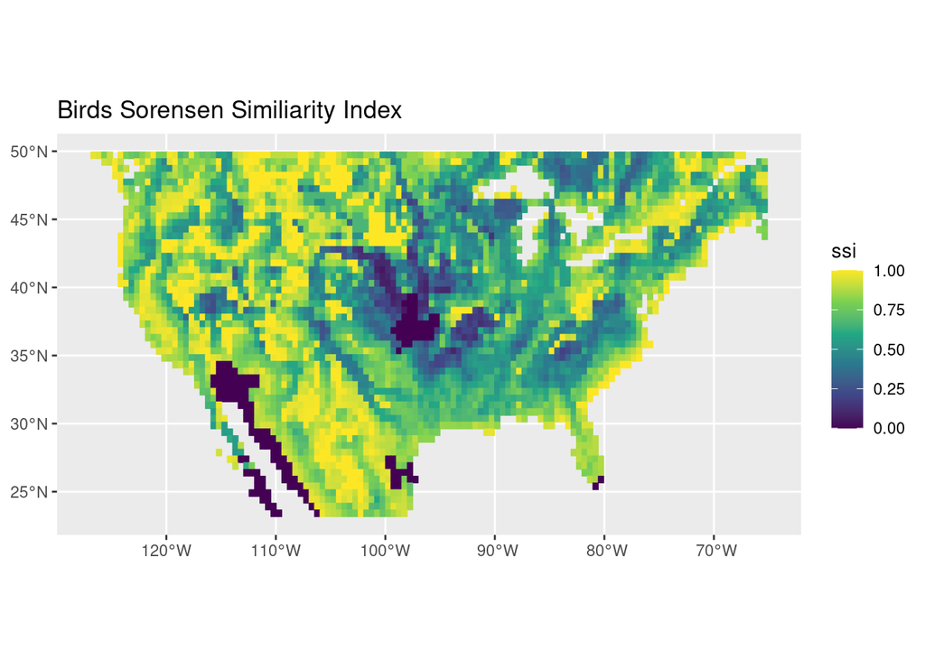

```r
ggplot() +
  geom_sf(data = pixel_spp_ssi_sf, aes(geometry = geometry, color = ssi, fill = ssi)) +
  scale_color_viridis_c() +
  scale_fill_viridis_c() +
  labs(title = "Birds Sorensen Similiarity Index")
```

### Add in the trait data

```r
# Read in AVONET dataset (reading in BirdLife tab, which should match with IUCN names)
avonet <- read_csv(here("data-laa", "AVONET-birdlife-tab-supplementary-dataset-1.csv")) %>%
  clean_names() %>%
  rename(avonet_spp = species1)
```

```r
# Read in  IUCN xwlk (created with Gemini and IUCN search engine)
lawler_iucn_avonet_xwlk <- read_csv(here("data-laa", "Lawler_IUCN_Avonet_xwlk_update.csv")) %>%
  clean_names() %>%
  rename(spp = lawler_spp) %>%
  mutate(spp = tolower(spp))
```

```r
# Combine files
pixel_spp_range_xwlk <- left_join(pixel_spp_range, lawler_iucn_avonet_xwlk)
pixel_spp_range_avonet <- left_join(pixel_spp_range_xwlk, avonet)
```

```r
pixel_spp_range_avonet_clean <- pixel_spp_range_avonet %>%
  dplyr::select(spp:avonet_spp, habitat:primary_lifestyle) %>%
  mutate(habitat_density = case_when(habitat_density == 1 ~ "Dense",
                                     habitat_density == 2 ~ "Semi-open",
                                     habitat_density == 3 ~ "Open")) %>%
  mutate(migration = case_when(migration == 1 ~ "Sedentary",
                               migration == 2 ~ "Partial",
                               migration == 3 ~ "Migratory"))
```

```r
# Combine the categorical columns into one group column to create unique groups
# Count up these trait groups by pixel
spp_trait_groups <- pixel_spp_range_avonet_clean  %>%
  unite(trait_group, migration, habitat_density, habitat, trophic_level, trophic_niche, primary_lifestyle) %>%
  group_by(pixel_id, juris, trait_group) %>%
  summarize(historical_trait_group_count = sum(historic_range),
            future_trait_group_count = sum(future_range)) %>%
  ungroup()
```

```r
# If we apply the Sorensen Similarity Index to traits, then we care about the presence / absence of a trait group and not the # of species
spp_trait_groups_ssi <- spp_trait_groups %>%
  mutate(historical_trait_group_presence = case_when(historical_trait_group_count == 0 ~ 0,
                                                     historical_trait_group_count != 0 ~ 1),
         future_trait_group_presence = case_when(future_trait_group_count == 0 ~ 0,
                                                     future_trait_group_count != 0 ~ 1)) %>%
  group_by(pixel_id, juris) %>%
  summarize(shared = sum(historical_trait_group_presence == 1 & future_trait_group_presence == 1),
            historical_trait_groups= sum(historical_trait_group_presence),
            future_trait_groups = sum(future_trait_group_presence),
            trait_group_ssi = (2 *shared)/(historical_trait_groups + future_trait_groups)) %>%
  ungroup()
```

```r
# Merge in pixel geography for map
trait_rast_sf_us_ssi <- inner_join(id_rast_sf, spp_trait_groups_ssi)
```

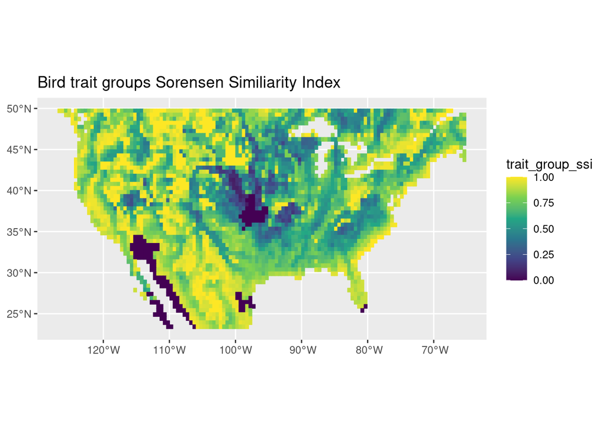

```r
# Create map
ggplot() +
  geom_sf(data = trait_rast_sf_us_ssi, aes(geometry = geometry, fill = trait_group_ssi, color = trait_group_ssi)) +
  scale_fill_viridis_c(limits = c(0,1)) +
  scale_color_viridis_c(limits = c(0,1)) +
  labs(title = "Bird trait groups Sorensen Similiarity Index")
```

### For VoCC species, what’s the change between trait SSI and species SSI?

If traits are compensating for some of the change in species similarity, then the difference between trait SSI and species SSI should be positive (more similarity between traits than species).

```r
pxl_ssi_dif <- left_join(spp_trait_groups_ssi%>%
                           dplyr::select(pixel_id, trait_group_ssi),
                         pixel_spp_ssi %>%
                           dplyr::select(pixel_id, ssi)) %>%
  mutate(ssi_diff = trait_group_ssi - ssi)
```

```r
# Merge in the pixel geography
id_rast_sf_us_ssi_diff <- inner_join(id_rast_sf, pxl_ssi_dif)
```

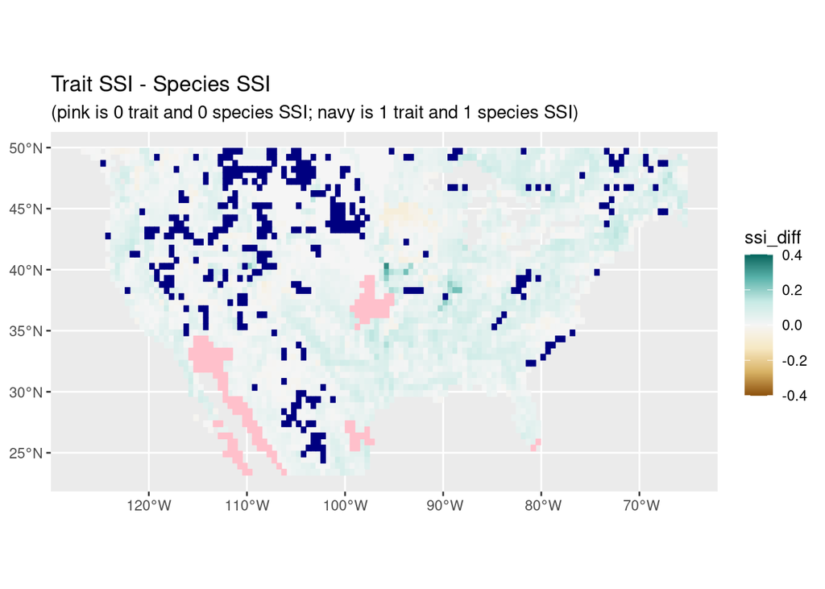

```r
ggplot() +
  geom_sf(data = id_rast_sf_us_ssi_diff, aes(geometry = geometry, fill = ssi_diff, color = ssi_diff), size = 0) +
  scale_color_distiller(palette = "BrBG", direction = 1, limits = c(-0.4, 0.4)) +
  scale_fill_distiller(palette = "BrBG", direction = 1, limits = c(-0.4, 0.4)) +
  # Show areas 0 species and trait overlap in pink
  geom_sf(data = id_rast_sf_us_ssi_diff %>%
            filter(ssi == 0 & trait_group_ssi == 0),
          aes(geometry = geometry), fill = "pink", color = "pink") +
  # Show areas with full species and trait overlap in navy
  geom_sf(data = id_rast_sf_us_ssi_diff %>%
            filter(ssi == 1 & trait_group_ssi == 1),
          aes(geometry = geometry), fill = "navy", color = "navy") +
  labs(title = "Trait SSI - Species SSI",
       subtitle = "(pink is 0 trait and 0 species SSI; navy is 1 trait and 1 species SSI)")
```

## Test out a more discrete set of traits

Use habtiat, trophic niche, and migratory status as the group traits.

```r
# Combine the categorical columns into one group column to create unique groups
# Count up these trait groups by pixel
spp_trait_groups_simple <- pixel_spp_range_avonet_clean  %>%
  unite(trait_group, migration, habitat, trophic_niche) %>%
  group_by(pixel_id, juris, trait_group) %>%
  summarize(historical_trait_group_count = sum(historic_range),
            future_trait_group_count = sum(future_range)) %>%
  ungroup()
```

```r
# If we apply the Sorensen Similarity Index to traits, then we care about the presence / absence of a trait group and not the # of species
spp_trait_groups_simple_ssi <- spp_trait_groups_simple %>%
  mutate(historical_trait_group_presence = case_when(historical_trait_group_count == 0 ~ 0,
                                                     historical_trait_group_count != 0 ~ 1),
         future_trait_group_presence = case_when(future_trait_group_count == 0 ~ 0,
                                                     future_trait_group_count != 0 ~ 1)) %>%
  group_by(pixel_id, juris) %>%
  summarize(shared = sum(historical_trait_group_presence == 1 & future_trait_group_presence == 1),
            historical_trait_groups= sum(historical_trait_group_presence),
            future_trait_groups = sum(future_trait_group_presence),
            trait_group_ssi = (2 *shared)/(historical_trait_groups + future_trait_groups)) %>%
  ungroup()
```

```r
# Merge in pixel geography for map
trait_rast_sf_us_simple_ssi <- inner_join(id_rast_sf, spp_trait_groups_simple_ssi)
```

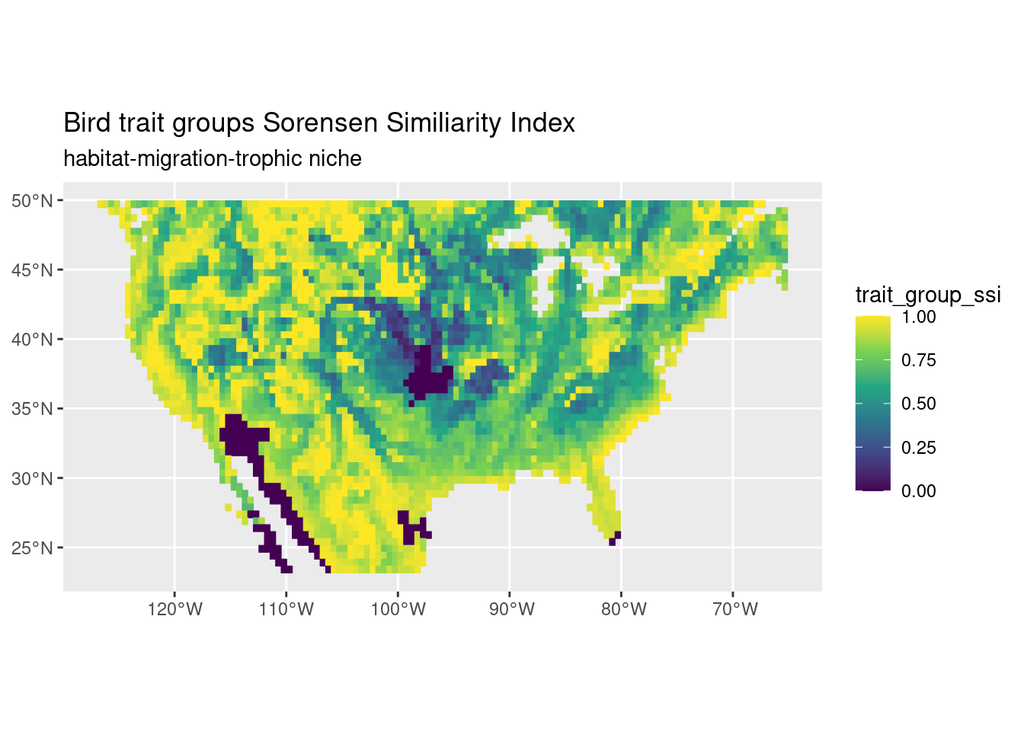

```r
# Create map
ggplot() +
  geom_sf(data = trait_rast_sf_us_simple_ssi, aes(geometry = geometry, fill = trait_group_ssi, color = trait_group_ssi)) +
  scale_fill_viridis_c(limits = c(0,1)) +
  scale_color_viridis_c(limits = c(0,1)) +
  labs(title = "Bird trait groups Sorensen Similiarity Index",
       subtitle = "habitat-migration-trophic niche")
```

Map has more yellow and is a little less chaotic with simplier trait groups.

### For VoCC species, what’s the change between simplier trait SSI and species SSI?

If traits are compensating for some of the change in species similarity, then the difference between trait SSI and species SSI should be positive (more similarity between traits than species).

```r
pxl_ssi_dif_simple <- left_join(spp_trait_groups_simple_ssi%>%
                           dplyr::select(pixel_id, trait_group_ssi),
                         pixel_spp_ssi %>%
                           dplyr::select(pixel_id, ssi)) %>%
  mutate(ssi_diff = trait_group_ssi - ssi)
```

```r
# Merge in the pixel geography
id_rast_sf_us_ssi_diff_simple <- inner_join(id_rast_sf, pxl_ssi_dif_simple)
```

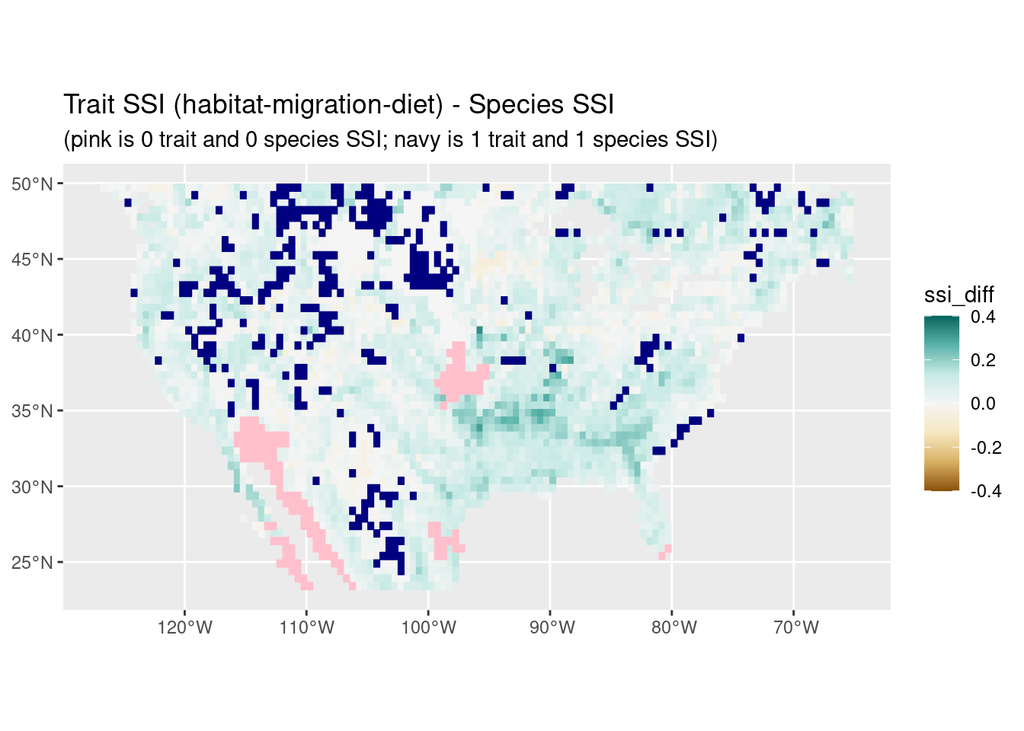

```r
ggplot() +
  geom_sf(data = id_rast_sf_us_ssi_diff_simple, aes(geometry = geometry, fill = ssi_diff, color = ssi_diff), size = 0) +
  scale_color_distiller(palette = "BrBG", direction = 1, limits = c(-0.4, 0.4)) +
  scale_fill_distiller(palette = "BrBG", direction = 1, limits = c(-0.4, 0.4)) +
  # Show areas 0 species and trait overlap in pink
  geom_sf(data = id_rast_sf_us_ssi_diff_simple %>%
            filter(ssi == 0 & trait_group_ssi == 0),
          aes(geometry = geometry), fill = "pink", color = "pink") +
  # Show areas with full species and trait overlap in navy
  geom_sf(data = id_rast_sf_us_ssi_diff_simple %>%
            filter(ssi == 1 & trait_group_ssi == 1),
          aes(geometry = geometry), fill = "navy", color = "navy") +
  labs(title = "Trait SSI (habitat-migration-diet) - Species SSI",
       subtitle = "(pink is 0 trait and 0 species SSI; navy is 1 trait and 1 species SSI)")
```

There’s more teal in this map with the simpler trait categories (trait categories are compensating more for loss of species similarity)